# R Notebook

```r
library(dplyr)
library(ggplot2)
library(gridExtra)
library(MASS)
library(fitdistrplus)
library(ggstatsplot)
library(tibble)
library(readr)
```

# Modelo Causal Tractos Esquizofrenia

Funciones

```r
logistic.regression.or.ci <- function(regress.out, level = 0.95) {
  usual.output <- summary(regress.out)
  z.quantile <- stats::qnorm(1 - (1 - level) / 2)
  number.vars <- length(regress.out$coefficients)
  OR <- exp(regress.out$coefficients[-1])
  temp.store.result <- matrix(rep(NA, number.vars * 2), nrow = number.vars)
  for (i in 1:number.vars) {
    temp.store.result[i, ] <- summary(regress.out)$coefficients[i] +
      c(-1, 1) * z.quantile * summary(regress.out)$coefficients[i + number.vars]
  }
  intercept.ci <- temp.store.result[1, ]
  slopes.ci <- temp.store.result[-1, ]
  OR.ci <- exp(slopes.ci)
  output <- list(
    regression.table = usual.output, intercept.ci = intercept.ci,
    slopes.ci = slopes.ci, OR = OR, OR.ci = OR.ci
  )
  return(output)
}
```

## Etapa 1 - definición de los datos expuestos y no expuestos

Esta parte realiza la lectura de datos y los convierte en trame

```r
# confusoras DAG= "sl2l_qa", "sl2l_iso","ecpl_qa", "ecpl_iso","age", "gender_F",
# features predictoras = "sl2l_diameter","ccbd_diameter","ifol_diameter","ecpl_volume","tral_volume","sl2l_mean_length","ccbd_mean_length"

setwd("C:/hcgalvan/Repositorios/hcgalvan_project/data/union/End")
temp = gsub(".*target.*", "", readLines("integrado.csv"))
data<-read.table(text=temp, sep=",", header=TRUE)

t<-data.frame(data[,c("sl2l_diameter","ccbd_diameter","ifol_diameter","ecpl_volume","tral_volume","sl2l_mean_length","ccbd_mean_length","label","sl2l_qa", "sl2l_iso", "ccbd_iso", "ccbd_qa", "ifol_qa", "ifol_iso", "ecpl_qa", "ecpl_iso", "tral_qa", "tral_iso", "afsl_qa", "afsl_iso", "afsr_qa", "afsr_iso", "cfpl_iso", "cfpl_qa", "cfpr_iso", "cfpr_qa", "fatl_iso", "fatl_qa", "fatr_iso", "fatr_qa", "slfl_iso", "slfl_qa", "slfr_iso", "slfr_qa", "tral_iso", "tral_qa", "ufsl_iso", "ufsl_qa", "ufsr_iso", "ufsr_qa", "age", "gender_F")])

t$gend_F <- ifelse(t$gender_F == "True", 1, 0) #convierto en = o 1
t <- subset(t, select = -c(gender_F)) # Quito de tabla
```

### Creación de features expuestos y no expuestos

Definición de nuevas variables como Expuesto y no Expuesto Se realizó estudio de cada variable: Su real distribución empírica Esta distribución se obtiene de los sujetos de control. las constantes definidas son el 1ero y 3er cuartil obtenida de distribución de densidad

False = No Expuesto = 0; True = Expuesto = 1

```r
t<- t %>%
  mutate(sl2ldmExp = if_else((t$sl2l_diameter > 22.10 & t$sl2l_diameter < 24.42), 0, 1))

t<- t %>%
  mutate(ccbdmExp = if_else((t$ccbd_diameter > 26.07 & t$ccbd_diameter < 30.23), 0, 1))

t<- t %>%
  mutate(ifoldmExp = if_else((t$ifol_diameter > 14.68 & t$ifol_diameter < 16.51), 0, 1))

t<- t %>%
  mutate(ecplvlExp = if_else((t$ecpl_volume > 6455 & t$ecpl_volume < 8918), 0, 1))

t<- t %>%
  mutate(tralvlExp = if_else((t$tral_volume > 12366 & t$tral_volume < 18004), 0, 1))

t<- t %>%
  mutate(sl2lmlExp = if_else((t$sl2l_mean_length > 72.18 & t$sl2l_mean_length < 80.61), 0, 1))

t<- t %>%
  mutate(ccbdmlExp = if_else((t$ccbd_mean_length > 112.62 & t$ccbd_mean_length < 123.81), 0, 1))
```

### Guardar datos para su estudio en InfoStat

El estudio que realizo en InfoStat es para determinar que variable predictora debe estar en la regresión y continuar el estudio por R. InfoStat me arroja rapidamente cuales son las confusoras más importantes

Dependerá de variable A y las confusoras.

```r
write.csv(t, "C:\\hcgalvan\\Repositorios\\hcgalvan_project\\data\\union\\End\\dbfmodelo.csv", row.names=FALSE)
```

### Creación de variable A a partir de los expuestos y no expuestos

OPCION 1: Variable con A con 5 features filtrados como expuestos.

t<- t %>% mutate(A = if_else((t$sl2ldmExp==1 & t$sl2lmlExp==1 & t$ccbdmExp==1 & t$ccbdmlExp==1 & t$tralvlExp==1),1, 0)) # No agrego ecpl porque contiene mucho ruido

t<- t %>% mutate(A = if_else((t$sl2ldmExp==1 & t$sl2lmlExp==1 & t$ccbdmExp==1 & t$ccbdmlExp==1 & t$tralvlExp==1 & t$ifoldmExp ==1),1, 0)) # No agrego ecpl porque contiene mucho ruido filter(t, A==1)

OPCION 3: Variable A Con una sola variable filtrada

```r
#t <- subset(t, select = -c(A)) # Quito de tabla
suma = 0
resultado <- c()
for (i in 1:length(t$label)){
  suma = sum(t$sl2ldmExp[i], t$sl2lmlExp[i], t$ccbdmExp[i], t$ccbdmlExp[i], t$tralvlExp[i], t$ecplvlExp[i], t$ifoldmExp[i] )
  resultado[length(resultado) + 1] <- if_else((suma >=1 ),1, 0)
}
t$A <- resultado
```

```r
t$Esquiz <- ifelse(t$label == 0, "SI", "NO")
t$sl2sdmd <- ifelse(t$sl2ldmExp == 0, "NO", "SI")
########################
xtabs(~sl2sdmd+Esquiz,t) #table of counts per stratum
```

```
       Esquiz
sl2sdmd NO SI
     NO 23 15
     SI 27 31
```

```r
odd <- ((31/27)/(15/23))
p <- (46/(23+15+27+31))
sprintf("odd: %f", odd)
```

```
[1] "odd: 1.760494"
```

```r
sprintf("log odd: %f", log(odd))
```

```
[1] "log odd: 0.565594"
```

```r
sprintf("Prob(Ezq): %f", p)
```

```
[1] "Prob(Ezq): 0.479167"
```

```r
v1 <- p*(27+31)
v2 <- (27+31)-v1
v3 <- p*(23+15)
v4 <- (23+15)-v3
pval <- 1-((v1/v2)/(v3/v3))
pval
```

```
[1] 0.08
```

```r
((11.2/128.8)/(198.7/17.3))
```

```
[1] 0.00757095
```

```r
########################
t$ccbdmd <- ifelse(t$ccbdmExp == 0, "NO", "SI")
xtabs(~ccbdmd+Esquiz,t) #table of counts per stratum
```

```
      Esquiz
ccbdmd NO SI
    NO 25 22
    SI 25 24
```

```r
odd <- ((24/25)/(22/25)) ### ERROR
p <- (46/(50+46))
sprintf("odd: %f", odd)
```

```
[1] "odd: 1.090909"
```

```r
sprintf("log odd: %f", log(odd))
```

```
[1] "log odd: 0.087011"
```

```r
sprintf("Prob(Ezq): %f", p)
```

```
[1] "Prob(Ezq): 0.479167"
```

```r
########################
t$ifoldmd <- ifelse(t$ifoldmExp == 0, "NO", "SI")
xtabs(~ifoldmd+Esquiz,t) #table of counts per stratum
```

```
       Esquiz
ifoldmd NO SI
     NO 23 16
     SI 27 30
```

```r
odd <- ((27/30)/(16/23)) ### ERROR
p <- ((27+16)/(30+23+27+16))
sprintf("odd: %f", odd)
```

```
[1] "odd: 1.293750"
```

```r
sprintf("log odd: %f", log(odd))
```

```
[1] "log odd: 0.257545"
```

```r
sprintf("Prob(Ezq): %f", p)
```

```
[1] "Prob(Ezq): 0.447917"
```

```r
########################
t$sl2lmld <- ifelse(t$sl2lmlExp == 0, "NO", "SI")
xtabs(~sl2lmld+Esquiz,t) #table of counts per stratum
```

```
       Esquiz
sl2lmld NO SI
     NO 25 22
     SI 25 24
```

```r
odd <- ((24/25)/(22/25)) ### ERROR
p <- ((24+22)/(25+25+24+22))
sprintf("odd: %f", odd)
```

```
[1] "odd: 1.090909"
```

```r
sprintf("log odd: %f", log(odd))
```

```
[1] "log odd: 0.087011"
```

```r
sprintf("Prob(Ezq): %f", p)
```

```
[1] "Prob(Ezq): 0.479167"
```

```r
########################
t$ecplvld <- ifelse(t$ecplvlExp == 0, "NO", "SI")
xtabs(~ecplvld+Esquiz,t) #table of counts per stratum
```

```
       Esquiz
ecplvld NO SI
     NO 26 16
     SI 24 30
```

```r
odd <- ((30/24)/(16/26)) ### ERROR
p <- ((30+16)/(24+26+30+16))
sprintf("odd: %f", odd)
```

```
[1] "odd: 2.031250"
```

```r
sprintf("log odd: %f", log(odd))
```

```
[1] "log odd: 0.708651"
```

```r
sprintf("Prob(Ezq): %f", p)
```

```
[1] "Prob(Ezq): 0.479167"
```

```r
########################
t$tralvld <- ifelse(t$tralvlExp == 0, "NO", "SI")
xtabs(~tralvld+Esquiz,t) #table of counts per stratum
```

```
       Esquiz
tralvld NO SI
     NO 24 19
     SI 26 27
```

```r
odd <- ((27/26)/(19/24)) ### ERROR
p <- ((27+19)/(26+24+27+19))
sprintf("odd: %f", odd)
```

```
[1] "odd: 1.311741"
```

```r
sprintf("log odd: %f", log(odd))
```

```
[1] "log odd: 0.271355"
```

```r
sprintf("Prob(Ezq): %f", p)
```

```
[1] "Prob(Ezq): 0.479167"
```

```r
########################
t$ccbdmld <- ifelse(t$ccbdmlExp == 0, "NO", "SI")
xtabs(~ccbdmld+Esquiz,t) #table of counts per stratum
```

```
       Esquiz
ccbdmld NO SI
     NO 24 13
     SI 26 33
```

```r
odd <- ((33/26)/(13/24)) ### ERROR
p <- ((33+13)/(26+24+33+13))
sprintf("odd: %f", odd)
```

```
[1] "odd: 2.343195"
```

```r
sprintf("log odd: %f", log(odd))
```

```
[1] "log odd: 0.851515"
```

```r
sprintf("Prob(Ezq): %f", p)
```

```
[1] "Prob(Ezq): 0.479167"
```

## Etapa 2: Regresion Logística con PCA - Expuestos (A)

Al trabajar solo con el features A, vamos a reducir con PCA las predictoras.

```r
### Son sujetos de estudio los seleccionados
t2 <- dplyr::select(dplyr::filter(t, label == 0), "sl2l_qa", "sl2l_iso", "ccbd_iso", "ccbd_qa", "ifol_qa", "ifol_iso", "ecpl_qa", "ecpl_iso", "tral_qa", "tral_iso", "afsl_qa", "afsl_iso", "afsr_qa", "afsr_iso", "cfpl_iso", "cfpl_qa", "cfpr_iso", "cfpr_qa", "fatl_iso", "fatl_qa", "fatr_iso", "fatr_qa", "slfl_iso", "slfl_qa", "slfr_iso", "slfr_qa", "tral_iso", "tral_qa", "ufsl_iso", "ufsl_qa", "ufsr_iso", "ufsr_qa", "age", "gend_F", "A")

### Son sujetos de control los seleccionados
t3 <- dplyr::select(dplyr::filter(t, label == 1), "sl2l_qa", "sl2l_iso", "ccbd_iso", "ccbd_qa", "ifol_qa", "ifol_iso", "ecpl_qa", "ecpl_iso", "tral_qa", "tral_iso", "afsl_qa", "afsl_iso", "afsr_qa", "afsr_iso", "cfpl_iso", "cfpl_qa", "cfpr_iso", "cfpr_qa", "fatl_iso", "fatl_qa", "fatr_iso", "fatr_qa", "slfl_iso", "slfl_qa", "slfr_iso", "slfr_qa", "tral_iso", "tral_qa", "ufsl_iso", "ufsl_qa", "ufsr_iso", "ufsr_qa", "age", "gend_F", "A")
```

### FORMA 2 Reg Logística con PCA para Sujetos de Estudio

```r
lista<-c("sl2l_qa", "sl2l_iso", "ccbd_iso", "ccbd_qa", "ifol_qa", "ifol_iso", "ecpl_qa", "ecpl_iso", "tral_qa", "tral_iso", "afsl_qa", "afsl_iso", "afsr_qa", "afsr_iso", "cfpl_iso", "cfpl_qa", "cfpr_iso", "cfpr_qa", "fatl_iso", "fatl_qa", "fatr_iso", "fatr_qa", "slfl_iso", "slfl_qa", "slfr_iso", "slfr_qa", "tral_iso", "tral_qa", "ufsl_iso", "ufsl_qa", "ufsr_iso", "ufsr_qa", "age", "gend_F")
pca.out2 <- prcomp(t2[,c(lista)],
                  scale. = TRUE)
pca.var2 <- pca.out2$sdev^2  #autovalores
# Cálculo de la varianza explicada acumulada
prop_varianza <- pca.out2$sdev^2/sum(pca.out2$sdev^2)
prop_varianza_acum <- cumsum(prop_varianza)
ggplot(data = data.frame(prop_varianza_acum, pc = factor(1:34)),
       aes(x = pc, y = prop_varianza_acum, group = 1)) +
  geom_point() +
  geom_line() +
  geom_label(aes(label = round(prop_varianza_acum,2))) +
  theme_bw() +
  labs(x = "Componentes principales",
       y = "Prop. varianza explicada acumulada")
```

[output not shown]

```r
misdatos <- data.frame(A = t2[, "A"], pca.out2$x[, 1:2])
logRegPCA <- glm(A ~ .,  data = misdatos, family = binomial)
#summary(logRegPCA)
logistic.regression.or.ci(logRegPCA)
```

```
$regression.table

Call:
glm(formula = A ~ ., family = binomial, data = misdatos)

Coefficients:
              Estimate Std. Error z value Pr(>|z|)
(Intercept)  2.657e+01  5.251e+04   0.001        1
PC1          5.007e-10  1.065e+04   0.000        1
PC2         -8.420e-11  2.523e+04   0.000        1

(Dispersion parameter for binomial family taken to be 1)

    Null deviance: 0.0000e+00  on 45  degrees of freedom
Residual deviance: 2.6687e-10  on 43  degrees of freedom
AIC: 6

Number of Fisher Scoring iterations: 25


$intercept.ci
[1] -102886.5  102939.6

$slopes.ci
          [,1]     [,2]
[1,] -20879.61 20879.61
[2,] -49450.17 49450.17

$OR
PC1 PC2
  1   1

$OR.ci
     [,1] [,2]
[1,]    0  Inf
[2,]    0  Inf
```

```r
summary(logRegPCA)$coefficients
```

```
                 Estimate Std. Error       z value  Pr(>|z|)
(Intercept)  2.656607e+01   52507.63  5.059469e-04 0.9995963
PC1          5.007351e-10   10653.06  4.700388e-14 1.0000000
PC2         -8.419936e-11   25230.14 -3.337253e-15 1.0000000
```

### Reg Logística con PCA para Sujetos de Control

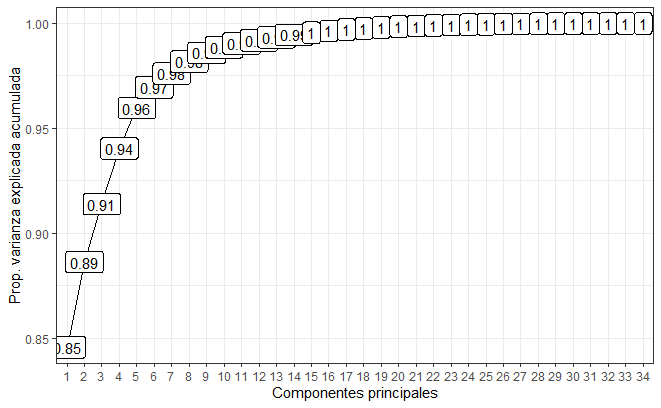

```r
pca.out3 <- prcomp(t3[,c(lista)],
                  scale. = TRUE)
#pca.out3$x
pca.var3 <- pca.out3$sdev^2  #autovalores
# Cálculo de la varianza explicada acumulada
prop_varianza <- pca.out3$sdev^2/sum(pca.out3$sdev^2)
prop_varianza_acum <- cumsum(prop_varianza)
ggplot(data = data.frame(prop_varianza_acum, pc = factor(1:34)),
       aes(x = pc, y = prop_varianza_acum, group = 1)) +
  geom_point() +
  geom_line() +
  geom_label(aes(label = round(prop_varianza_acum,2))) +
  theme_bw() +
  labs(x = "Componentes principales",
       y = "Prop. varianza explicada acumulada")
```

```r
NA
NA
NA
NA
```

```r
#pca.var3
misdatos2 <- data.frame(A = t3[, "A"], pca.out3$x[, 1:2])
#pca.out3[1]
logRegPCANoExp <- glm(A ~ .,  data = misdatos2, family = binomial)
#summary(logRegPCA)
logistic.regression.or.ci(logRegPCANoExp)
```

```
$regression.table

Call:
glm(formula = A ~ ., family = binomial, data = misdatos2)

Coefficients:
            Estimate Std. Error z value Pr(>|z|)
(Intercept)   4.1555     1.3726   3.027  0.00247 **
PC1           0.2659     0.1872   1.420  0.15549
PC2           0.6025     0.7347   0.820  0.41218
---
Signif. codes:  0 ‘***’ 0.001 ‘**’ 0.01 ‘*’ 0.05 ‘.’ 0.1 ‘ ’ 1

(Dispersion parameter for binomial family taken to be 1)

    Null deviance: 16.794  on 49  degrees of freedom
Residual deviance: 13.560  on 47  degrees of freedom
AIC: 19.56

Number of Fisher Scoring iterations: 7


$intercept.ci
[1] 1.465277 6.845771

$slopes.ci
           [,1]      [,2]
[1,] -0.1010014 0.6327851
[2,] -0.8374657 2.0424311

$OR
     PC1      PC2
1.304594 1.826648

$OR.ci
          [,1]     [,2]
[1,] 0.9039317 1.882847
[2,] 0.4328060 7.709329
```

```r
summary(logRegPCANoExp)$coefficients
```

```
             Estimate Std. Error   z value    Pr(>|z|)
(Intercept) 4.1555238  1.3726001 3.0274832 0.002465994
PC1         0.2658919  0.1871939 1.4204089 0.155488681
PC2         0.6024827  0.7346811 0.8200602 0.412181789
```

## Etapa 2: Generación Propensity Z score

Aquí es un trabajo manual para cada prueba a realizar. Cada regresión tiene que ser ajustada.

### Generación de Z Score

Usar una de ellas. La que mejor se ajusta a los datos.

### Con PCA

```r
exp(-26.56+(-9.21)*5.007351e-10)+(-8.419936e-11*(-1.267105))
```

```
[1] 1.096078e-10
```

#### Armado de Subclases del Zscore para estudio posterior

Tener en cuenta que se puede dividir de manera diferente, por otra cantidad de estratos como por ejemplo spline.

```r
#########
# Utilizo t2 - sujetos de estudio
# Entonces utilizo el total
cuantil <-quantile(t2$zscore)
t2$subclass <- cut(x=t2$zscore,
                              breaks=quantile(cuantil,
                              prob = seq(0, 1, 1/5)),include.lowest=T)
```

[output not shown]

```r
write.csv(t2, "C:\\hcgalvan\\Repositorios\\hcgalvan_project\\data\\union\\End\\dbcasespieceswice.csv", row.names=FALSE) ##guardo los casos
write.csv(t3, "C:\\hcgalvan\\Repositorios\\hcgalvan_project\\data\\union\\End\\dbcontrolpieceswice.csv", row.names=FALSE) ##guardo los sujetos de control
```

### Espacio para utilizar con función constante por partes.

```r
setwd("C:/hcgalvan/Repositorios/hcgalvan_project/data/union/End")
temp = gsub(".*target.*", "", readLines("dbcasespieceswice.csv"))
data<-read.table(text=temp, sep=",", header=TRUE)
dz<-data.frame(data[,c("D","A","zscore","subclass")])
pcwstd<-data.frame(dz)
```

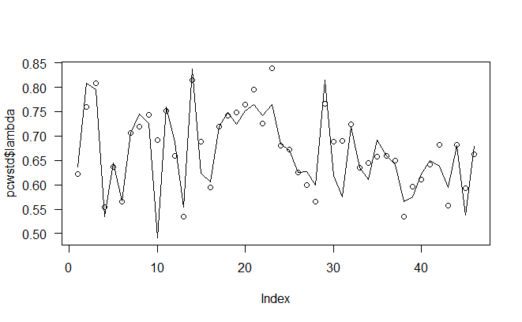

```r
deri_pol1 <- function(x){-6.122264 + 17.67111*x - 18.56562*x^2 + 10.44433*x^3 - 3.536183*x^4 + 0.7576271*x^5 - 0.1036324*x^6 + 0.008774759*x^7 - 0.000418757*x^8 + 8.6019e-06*x^9}

deri_pol2 <- function(x){-0.2197296 + 2.0046*x - 1.811326*x^2 + 0.8375173*x^3 - 0.2182443*x^4 + 0.03246031*x^5 - 0.002569767*x^6 + 8.38559e-05*x^7}

deri_pol3 <- function(x){4.793893 - 11.81498*x + 14.1384*x^2 - 9.532235*x^3 + 4.068752*x^4 - 1.159912*x^5 + 0.2257844*x^6 -  0.03004852*x^7 + 0.002683565*x^8 - 0.0001534813*x^9 + 5.071574e-06*x^10 - 7.35409e-08*x^11 }

deri_pol4 <- function(x){2.512275 - 4.393058*x + 4.022133*x^2 - 1.838199*x^3 + 0.4632213*x^4 - 0.06537888*x^5 + 0.004842031*x^6 - 0.0001464992*x^7}

deri_pol5 <- function(x){-4.94969 + 13.71929*x - 12.46775*x^2 + 5.722334*x^3 - 1.45807*x^4 + 0.2089239*x^5 - 0.01574029*x^6 + 0.0004847141*x^7}

### Obtengo los límites de zscore a partir del filtro subclase y utilizar en la función por partes

lim1 <- max(as.numeric(unlist(dplyr::select(dplyr::filter(pcwstd, subclass == 1,),"zscore"))))
lim2 <- max(as.numeric(unlist(dplyr::select(dplyr::filter(pcwstd, subclass == 2,),"zscore"))))
lim3 <- max(as.numeric(unlist(dplyr::select(dplyr::filter(pcwstd, subclass == 3,),"zscore"))))
lim4 <- max(as.numeric(unlist(dplyr::select(dplyr::filter(pcwstd, subclass == 4,),"zscore"))))
lim5 <- max(as.numeric(unlist(dplyr::select(dplyr::filter(pcwstd, subclass == 5,),"zscore"))))


posicionax <- function(x, pos){
  v <- NULL
  h <- NULL
  h<-as.numeric(unlist(dplyr::select(dplyr::filter(pcwstd, subclass == pos,),"zscore")))
  div.1 <- round((h[order(h, decreasing = FALSE)] / x),4)
  v<- which(div.1 == 1.0000,)
  v
}

buscarx <- function(x){
    d <- NULL
    ifelse (x > 0 & x<= lim1, d <- posicionax(x, 1), 0)
    ifelse (x>lim1 & x<=lim2, d <- posicionax(x, 2), 0)
    ifelse (x>lim2 & x<=lim3, d <- posicionax(x, 3), 0)
    ifelse (x>lim3 & x<=lim4, d <- posicionax(x, 4), 0)
    ifelse (x>lim4, d <- posicionax(x, 5), 0)
    d
}

fx <- function(x, dat){
    f <- NULL
    ifelse (x > 0 & x<= lim1, f <- deri_pol1(dat), 0)
    ifelse (x>lim1 & x<=lim2, f <- deri_pol2(dat), 0)
    ifelse (x>lim2 & x<=lim3, f <- deri_pol3(dat), 0)
    ifelse (x>lim3 & x<=lim4, f <- deri_pol4(dat), 0)
    ifelse (x>lim4, f <- deri_pol5(dat), 0)
    f
}

x <- data.frame(pcwstd$zscore)
for(i in 1:nrow(x)) {       # for-loop over rows
  dat <- buscarx(pcwstd$zscore[[i]])
  #print(dat)
  #print(fx(pcwstd$zscore[[i]], dat))
  lambd <-fx(pcwstd$zscore[[i]], dat)
  pcwstd$lambda[i] <- lambd
  }

plot(pcwstd$lambda, type="l", las=1)
points(x)
```

```r
NA
NA
```

#### Generar Constante Delta

Se utiliza o genera despues de realizar la regresión

```r
delta
```

```
[1] 1.28239
```

## Modelo Final

El modelo final tiene algunas dificultades, con respecto a si es por cada sujeto o es el total de sujetos.

Deberíamos tener dos calculos

[figure not shown]